# 実験B(大草班) 解析ツールの使用方法

k.konda

2023/05/17

本説明はWindows環境で作成しています。 Macユーザは適宜対応すること。

また、アプリケーションの不具合を見つけた場合は、逐次報告をお願いいたします。

# 1 準備

## 1.1 Rのインストール（Rがインストールされていない場合）

manabaにあるリンクよりGoogle Driveにアクセスし、「解析ツール」フォルダから「R-x.x.x-win.exe」をダウンロードし、インストールする。

- x.x.x はバージョン数のため、時々により異なります。

あるいは、[The R Project for Statistical ComputingのDownload](https://cran.ism.ac.jp/) より、自分のOSに適したインストールファイルをダウンロードし、インストールする。

## 1.2 解析ツールの準備

「解析ツール」フォルダより「jikkenB_ookusa.zip」をダウンロードし、解凍する。 解凍が完了したら、Cドライブ直下に解凍された「jikkenB_ookusa」フォルダを配置する。

- 圧縮ファイルの解凍方法がわからない場合は、[ファイルを展開（解凍）する方法](https://www.pc-koubou.jp/magazine/39336#section02) などを参照のこと。
- ワーキングディレクトリについて知見があり、自身で適切にRスクリプトを書き換えられる場合は、そうしてもよい（その場合、サポートは行いません）。
- 解凍した際、「jikkenB_ookusa」フォルダの中に「jikkenB_ookusa」フォルダが作成されることがあるが、その場合は中のフォルダのみをCドライブに配置すること。

[figure not shown]

Fig.1. jikkenB_ookusaフォルダのパス例

ここでアドレスバーが上の画像のようになっていればok。（Cドライブ名、画像の場合「OS」は環境により異なる）

## 1.3 解析ツールの実行

「jikkenB_ookusa」フォルダ内の「app.R」をRで開く。

[figure not shown]

Fig.2. ファイル -> スクリプトを開く

1. スタートメニューからインストールした「R x.x.x」を選択。
2. R Guiウィンドウが開いたら、左上の「ファイル」→「スクリプトを開く」を選択し、Cドライブに配置した「jikkenB_ookusa」フォルダから「app.R」を選択して「開く」。
3. 「Rエディタ」ウィンドウ2行目の `setwd("C:/jikkenB_ookusa/")` の行をクリックまたは行全体を選択し、「編集」->「カーソル行または選択中のRコードを実行」を選択し、実行する。
   - 「No such file or directory」のエラーが出る場合、「1.2 解析ツールの準備」のフォルダの配置が上手くいっていない可能性があるので、見直してください。
   - 選択肢の右にある「Ctrl+R」はショートカットキーで、これでも実行できる。
   - 「1.2 解析ツールの準備」でフォルダの配置を自身の判断で行った者は、書き換えを忘れないこと。

[figure not shown]

Fig.3. 編集 -> コードを実行

4. `source("Rscripts/package.R", encoding="UTF-8")` を実行し、アプリケーション実行に必要なパッケージをインストールする。実行の際、「CRAN mirrors」ウィンドウが出た場合は、「Japan」のいずれかを選択し「OK」すること。
   - ここでエラーが出る場合、パソコンのユーザー名に2byte文字(日本語や全角スペースなど)が使用されている可能性があります。該当する場合は、以下のサイトなどを参考に解決すること。

   [Windowsで日本語のユーザ名を使っている時のRパッケージインストール場所問題](https://b.okadajp.org/2021/05/13/windowsderi-ben-yu-noyuzaming-woshi-tuteirushi-norpatukeziinsutoruchang-suo-wen-ti/?fbclid=IwAR16bXSIw50NPPTyh0HJwJN2OvOiqfqolWaqdZWWM8Bt0cTo-xIr9EgjaC8)
5. 使用しているパソコンにPythonがインストールされていない場合（不明な場合も）、`reticulate::install_miniconda()`, `reticulate::py_install("pandas")` の2行の行頭にある `#` を削除し、実行すること。
   - 4.でユーザー名の2byte文字によるエラーが出た場合、ここでもエラーが出ます。その場合は、`reticulate::install_miniconda()` の括弧内に引数 `path=”C:/”` を追記すること。
   - この2行は次回以降のアプリケーション起動時に邪魔になるため、 `#` を書き直しておくこと (コメントアウト)。
6. 以降の行をすべて実行し（全行を選択し一括で実行してもよい）、インターネットブラウザが立ち上がり、左上に「Motion Data」とあればアプリケーション実行成功です。

# 2 分析

本アプリケーションは、実験B「ストリームデータ解析・実装（大草班）」で撮影し、動作解析して作成された「.pkl」データ専用の分析ツールです。それ以外のファイルは読み込めません。また、画面サイズは 1920x1080 を想定して設計しています。基本的には全画面表示で使用してください。

## 2.1 解析の開始

1. 分析に使用するデータは、「jikkenB_ookusa/pkl」フォルダ内もしくは、デスクトップに配置してください。（基本的にはアプリケーション配布時にpklフォルダ内に配置してあります）
2. 分析したい動作のファイル名をリストボックス（読込ファイル名①②）から選択もしくは入力し、「Submit」ボタンを押してください。選択・入力は①だけでも（②が空欄でも）実行可能です。
   - データの読み込みおよび描画用の演算を行うため、使用しているパソコンによっては、完了までに時間がかかります。
   - **最初に「Error: [object Object]」と表示されますが、仕様**です。データの読み込みが終わるまでお待ちください。
   - 以降、「読込ファイル名」欄を書き換えた際は必ず「Submit」ボタンを押してください。

[figure not shown]

Fig.4. 読込ファイル名の入力・選択

## 2.2 解析用タブ

### 2.2.1 1フレーム分析

動画の1フレームにおける身体の各部位の位置の可視化を行います。1秒当たりのフレーム数は撮影機器の設定を確認すること（GoProならデフォルトで1秒あたり240フレームと思われます）。

- 「全般設定/2ファイルのフレーム数を合わせる」を「はい」にすると、2ファイルのフレーム数が等しくなるよう換算が行われ、2ファイルの動作がだいたい一致します。
- 身長差によって比較がしづらい場合は、「全般設定/2ファイルの身長帯を合わせる」を「はい」にしてください。ただし、撮影環境と映像から換算したものであるため、厳密な数値ではありません。参考程度にしてください。
- 「1フレーム分析・軌跡分析用/描画部位選択」でいくつかの部位を指定すると、指定した部位のみプロットされるようになります。
- 「1フレーム分析・軌跡分析用/描画フレーム指定」のスライダーバーによって、可視化するタイミングを指定することができます。
- 「1フレーム分析・軌跡分析用/描画フレーム指定」のスライダーバー下にある「Start/Pause」ボタンによって、1フレームずつコマ送りに再生することができます。ただし、パソコンのスペックによって描画が終わるまでにかかる時間やコマ送りの速度が異なるため、注意してください。
- 「1フレーム分析・軌跡分析用/骨格を表示する」によって、簡易的あるいは全ての部位のプロットをつなげる骨格線を追記することができます。

[figure not shown]

Fig.5. 1フレーム分析タブ画面・パラメータ調整欄

### 2.2.2 軌跡分析

解析した動画内で身体の各部位がどのような軌跡で運動したかの可視化を行う。操作方法は基本的に1フレーム分析と同様。

- 部位の軌跡が細かく変化し考察しづらい場合は、「全般設定/座標をスプライン補間する」で推定座標を用いると考察しやすくなるかもしれません（悪化することも多々あります）。

[figure not shown]

Fig.6. 軌跡分析タブ画面・パラメータ調整欄

### 2.2.3 運動量分析

身体の各部位について、運動中の変位・速度・加速度の可視化を行う。運動量の単位は、サイドバーで設定したmmもしくはpxと、単位あたりフレーム数に従う。 y軸で示す運動量の正負方向は、1フレーム分析・軌跡分析のグラフと同じです。

- 「運動量分析用/描画部位指定」で運動量を計算する部位を指定する。
- 「運動量分析用/描画する運動量を選択」でブラフに示したい変位・速度・加速度を選択する。
- 基本的には2ファイルの運動時間は合わないため、運動時間を合わせるために「全般設定/2ファイルのフレーム数を合わせる」を「はい」で分析することを推奨する。

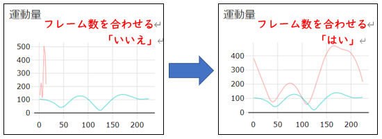

Fig.7. フレーム数を統一(補間)する

- 波形が細かく変化し考察がしづらい場合は、「全般設定/平滑化曲線を表示する」で平滑化を行うといくらか考察しやすくなるかもしれません。

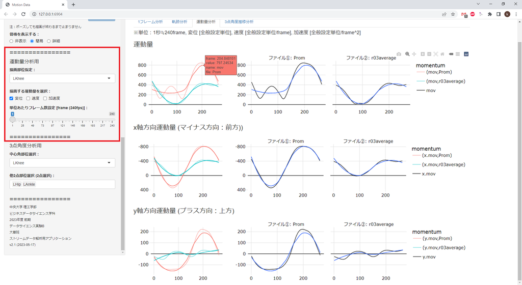

Fig.8. 運動量分析タブ画面・パラメータ調整欄

### 2.2.4 角度推移分析

選択した3部位について、中心角の角度の推移の可視化を行う。操作方法は基本的に1フレーム分析と同様。

- 分析対象について、中心角としたい部位を点角度分析用/中心角部位選択」、残り2点を「角度分析用/他2点部位選択」で選択する。「角度分析用/他2点部位選択」で1点以下あるいは3点以上の選択をした場合はグラフが描画されない。

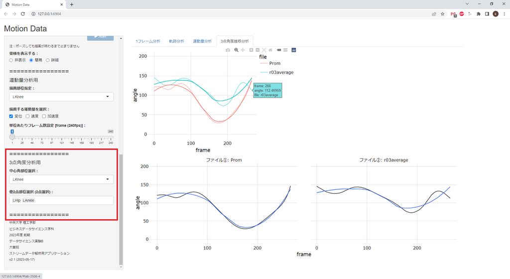

Fig.9. 角度推移分析タブ画面・パラメータ調整欄

# 3 付録

身体の部位の名称と位置の関係は、下図参照。

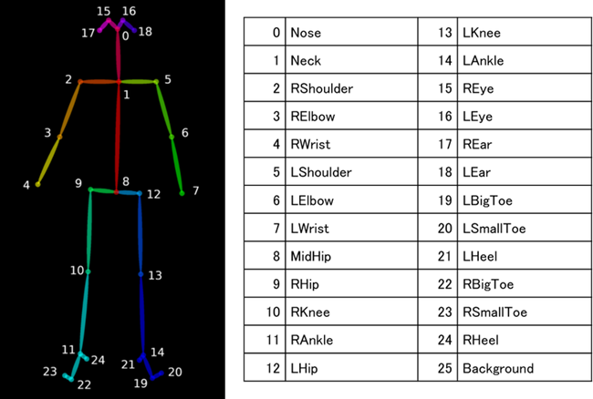

# 4 更新